# SurvivalDNN Usage Example

```python
import numpy as np
import pandas as pd
import matplotlib.pyplot as plt
np.random.seed(42)
```

## Data

In this simple example, suppose a widget factory produces widgets of various *length*, *width*, and *widget factor*. We observe these widget-level characteristics as features $X$, as well as their failure times $Y$. The goal is to draw inferences or make estimates regarding the distribution $P(Y > t|X)$.

```python
def generate_synthetic_data(n=100):

    # Observed features
    length = np.random.uniform(1., 8., size=n)
    width = np.random.uniform(0.5, 4., size=n)
    widget_factor = np.random.uniform(0.2, 2., size=n)
    X = np.stack([length, width, widget_factor], axis=-1)

    # True DGP (Unobserved)
    epsilon = np.random.normal(0, 0.1,size=n)
    U = 1 - 0.1*length - 0.1*width - widget_factor + epsilon
    rate = np.exp(U)

    # Observed outcomes
    Y = np.exp(-rate) * 10

    return X, Y

X, Y = generate_synthetic_data(n=10000)
```

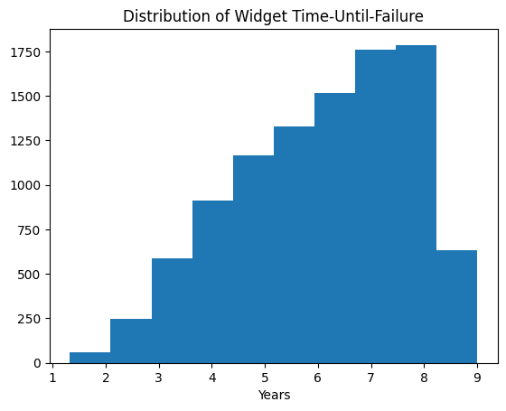

```python
plt.hist(Y)
plt.title('Distribution of Widget Time-Until-Failure')
plt.xlabel('Years')
plt.show()
```

## Model

```python
from survivaldnn import SurvivalDNNModel
```

```python
model = SurvivalDNNModel()
```

### Discretization

One important consideration is `numSupport`, which determines the number of support points used to discretize the outcome space. The output of the neural network is of the form $$ P(Y > t_1|X), P(Y > t_2|X), ..., P(Y > t_{numSupport} | X) $$ If it is too small, too many observations are combined into one bin and we lose precision. If it is too large, there may be very few observations in some bins and we lose efficiency or get noisy estimates.

```python
# Internally, this is used to determine the support points
# t_1, t_2, ..., t_{numSupport}
support = model.discretize_outcome_support(Y, numSupport=10)
support
```

```
array([1.32513751, 3.83058098, 4.6781604 , 5.39642685, 6.00376299,
       6.57914055, 7.09105098, 7.54190942, 7.99987867, 9.00493482])
```

### Compilation

Next we compile the neural network model by specifying its architecture, regularization, loss function, and other hyperparameters. The default is a fully-connected residual network with batch normalization, leaky ReLU activations, and ADAM optimizer. For additional documentation, see `help(model.compile)`.

```python
numFeatures = X.shape[-1]
model.compile(numFeatures=numFeatures,
              numSupport=100,
              loss='loglik',
              architecture='resnet',
              layers=5)
```

### Train

Finally we can train the model using the dataset. The previous step in this example specified that we are minimizing negative loglikelihood. For more prediction-focused tasks where importance is more on point-estimates, alternative loss functions include `mse` or custom callables.

```python
# Standardize features
X = (X - X.mean(axis=0)) / X.std(axis=0)
```

```python
# Train the model
model.fit(X, Y,
          epochs=2000)
```

## Inference

After training, we can then estimate statistics of interest from the learned distribution $\hat{P}(Y > t|X)$.

### Point Estimates/Predictions

Estimation of $\hat{\mathbb{E}}_n[Y|X=x]$ can be done with `.predict`.

In the widget factory application, this is the expected failure time for a given widget with features $x$.

```python
Y_hat = model.predict(X)
```

```python
def compare_predictions(res):
    fig, ax = plt.subplots(figsize=(12,7))
    ax.set_xlim((0,10))
    ax.set_ylim((0,10))
    res.plot.scatter(x='True', y='Predicted', ax=ax)
    a, b = res.min().max(), res.max().min()
    plt.plot([a, b], [a, b], 'r--', lw=2, label='Perfect Prediction')
    plt.legend()
    plt.show()
```

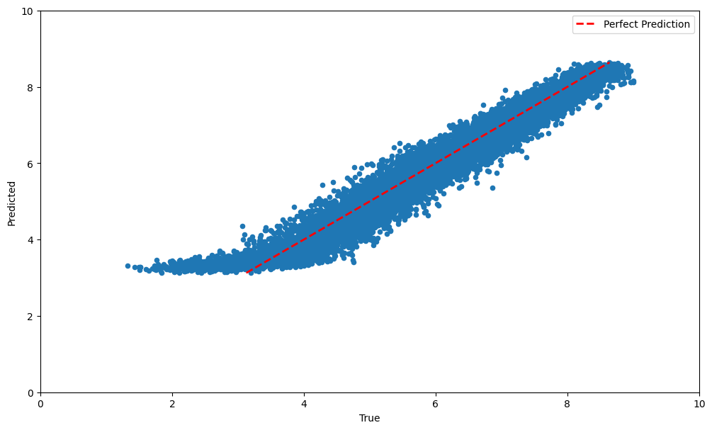

```python
res = pd.DataFrame(np.stack([Y, Y_hat], axis=-1), columns=['True', 'Predicted'])
compare_predictions(res)
```

### Conditional Point Estimates/Predictions

In some scenarios, we know that *at least* $t$ time has passed before failure which we may wish to incorporate to improve estimates. Estimation of $\hat{E}_n[Y|X=x, Y>t]$ can be done with `.predict_conditional`.

In the widget factory application, this is the expected failure time for a given widget with features $x$ *given that at least* $t$ time has already passed.

```python
# Suppose we inspected widgets halfway and
# observed they haven't failed yet
elapsed = Y / 2
Y_hat_cond = model.predict_conditional(X, elapsed)
```

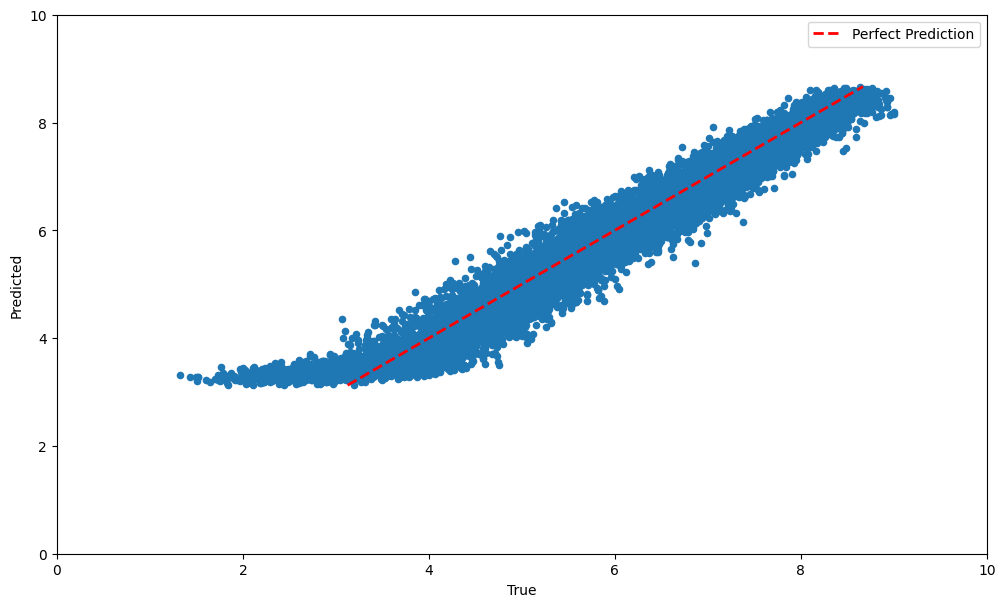

```python
res = pd.DataFrame(np.stack([Y, Y_hat_cond], axis=-1), columns=['True', 'Predicted'])
compare_predictions(res)
```

### Survival Function

The survival function $S(t|X) = P(Y >= t|X)$ can be estimated and plotted with `.predict_survival_function` and `.plot_survival_function`.

```python
survFunc, support = model.predict_survival_function(X[:100,:])
```

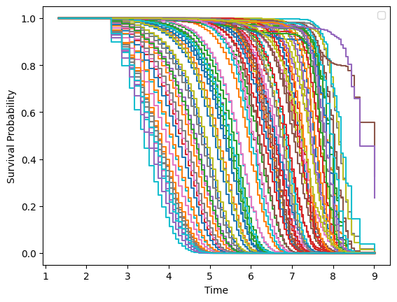

```python
model.plot_survival_function(X[:100,:])
```

### Cumulative Distribution Function

The closely related CDF $P(Y < t| X)$ can be plotted with `.plot_distribution`.

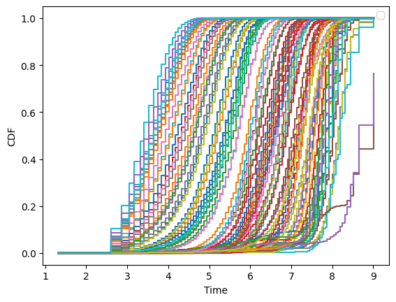

```python
model.plot_distribution(X[:100,:])
```